# Homework 2: NBA Data Visualization Part 2

Data Analytics and Visualization, Fall 2024

Author

Affiliation

Hayley Walters, Anjeli Mayoraz

Harvey Mudd College

Published

October 30, 2024

# NBA Statistics: Analyzing and Visualizing Individual Player Statistics

## Motivation

The National Basketball Association (NBA) is home to some of the most elite athletes in the world, with player salaries reflecting their exceptional talent, marketability, and contributions to their teams. However, the factors influencing these salaries often extend beyond performance, encompassing physical characteristics, playing time, and positional roles. This report delves into the intricate relationships between NBA player salaries and various attributes, including height, weight, minutes played, and the positions players occupy on the court.

By examining these connections, we aim to uncover patterns and insights that shed light on how player attributes impact their value in the league. Additionally, this report features an interactive tool that allows readers to input their height and weight to discover the NBA position most suited to their physical profile, providing a fun and engaging way to explore the data.

Through visualizations and analysis, this report aims to present a comprehensive perspective on the dynamic interplay of physical traits, performance metrics, and financial considerations in professional basketball.

## Setup

First we include our necessary imports:

```python
from plotnine import *
import numpy as np
import pandas as pd
from scipy.stats import norm
```

Then we read in a CSV file of our NBA game data. This is from the Kaggle NBA basketball dataset and we are using the data file “game.csv”. [Here’s the link](https://www.kaggle.com/datasets/wyattowalsh/basketball).

```python
# load game data
game = pd.read_csv('game.csv')
# game.head()
```

```python
# load player data
player = pd.read_csv('common_player_info.csv')
# player.head()
```

```python
draft = pd.read_csv('draft_history.csv')
# draft.head()
```

```python
pstats = pd.read_csv('draft_combine_stats.csv')
# pstats.head()
```

```python
position_stats = pstats.groupby('position')[['height_wo_shoes', 'weight']].describe()
position_stats
```

| position | height_wo_shoes count | height_wo_shoes mean | height_wo_shoes std | height_wo_shoes min | height_wo_shoes 25% | height_wo_shoes 50% | height_wo_shoes 75% | height_wo_shoes max | weight count | weight mean | weight std | weight min | weight 25% | weight 50% | weight 75% | weight max |
| --- | --- | --- | --- | --- | --- | --- | --- | --- | --- | --- | --- | --- | --- | --- | --- | --- |
| C | 98.0 | 82.239796 | 1.859400 | 78.50 | 80.8125 | 82.125 | 83.2500 | 89.25 | 98.0 | 250.345918 | 22.414305 | 206.4 | 236.70 | 248.60 | 264.00 | 314.0 |
| C-PF | 44.0 | 81.693182 | 1.239917 | 79.00 | 80.7500 | 81.625 | 82.2500 | 85.25 | 44.0 | 240.006818 | 11.137959 | 217.0 | 230.95 | 240.25 | 248.40 | 264.2 |
| PF | 205.0 | 79.771951 | 1.342237 | 76.50 | 78.7500 | 79.750 | 80.7500 | 85.25 | 205.0 | 232.828293 | 16.641614 | 174.4 | 221.80 | 233.40 | 243.00 | 280.0 |
| PF-C | 46.0 | 81.048913 | 1.172153 | 78.25 | 80.2500 | 81.250 | 81.7500 | 83.50 | 46.0 | 244.676087 | 19.747283 | 207.2 | 233.25 | 243.30 | 253.55 | 302.6 |
| PF-SF | 34.0 | 79.977941 | 1.285655 | 77.25 | 79.0625 | 80.000 | 80.7500 | 82.25 | 34.0 | 227.776471 | 17.453159 | 193.0 | 216.25 | 229.80 | 239.75 | 263.0 |
| PG | 194.0 | 72.863402 | 1.873949 | 67.75 | 71.7500 | 73.000 | 74.0000 | 77.75 | 194.0 | 186.207732 | 12.595397 | 154.4 | 177.00 | 186.00 | 195.50 | 227.2 |
| PG-SG | 40.0 | 74.250000 | 2.008795 | 70.50 | 72.8750 | 73.875 | 75.4375 | 78.50 | 40.0 | 192.440000 | 12.860291 | 165.2 | 182.50 | 192.80 | 199.40 | 221.8 |
| SF | 141.0 | 78.290780 | 1.212886 | 75.50 | 77.5000 | 78.250 | 79.2500 | 81.50 | 141.0 | 215.002128 | 13.911308 | 179.2 | 206.60 | 215.00 | 222.60 | 254.4 |
| SF-PF | 41.0 | 79.201220 | 1.601971 | 75.75 | 78.2500 | 79.000 | 80.2500 | 83.50 | 41.0 | 221.397561 | 14.670898 | 190.0 | 211.00 | 222.20 | 229.00 | 257.2 |
| SF-SG | 33.0 | 77.356061 | 1.017484 | 74.75 | 76.7500 | 77.250 | 78.0000 | 80.00 | 33.0 | 210.321212 | 13.626072 | 185.0 | 200.00 | 210.40 | 221.80 | 241.4 |
| SG | 190.0 | 75.817105 | 1.156319 | 72.75 | 75.0000 | 75.750 | 76.5000 | 79.00 | 189.0 | 200.715344 | 13.155519 | 163.2 | 192.60 | 200.80 | 210.00 | 235.4 |
| SG-PG | 25.0 | 74.680000 | 1.362672 | 71.75 | 74.0000 | 74.500 | 75.5000 | 78.50 | 25.0 | 193.496000 | 12.984750 | 166.2 | 183.20 | 194.60 | 202.80 | 223.0 |
| SG-SF | 61.0 | 76.856557 | 1.062092 | 74.25 | 76.2500 | 76.750 | 77.5000 | 79.25 | 61.0 | 206.413115 | 11.837166 | 174.4 | 198.60 | 206.00 | 214.60 | 228.0 |

[output not shown]

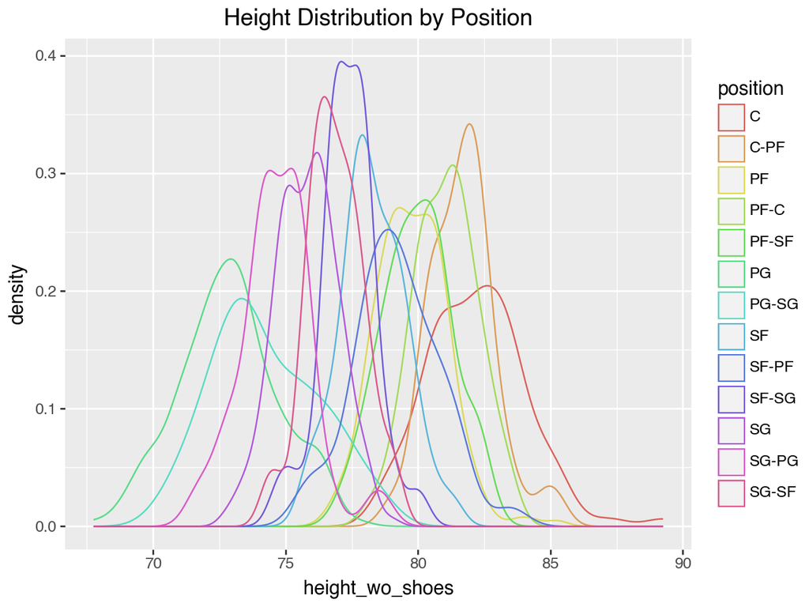

```python
p = ggplot(pstats, aes(x='height_wo_shoes', color='position')) + geom_density() + ggtitle('Height Distribution by Position')
p.show()
```